# We rate dogs analysis

## By: Abdullah Walied Allama

## Introduction:

"We rate dogs" is a twitter account that rates dogs sent by the account's followers. The rating of these dogs is with a denominator of 10 and a numerators that is larger than that (e.g., 11/10, 12/10, 13/10, etc...). The reason for this unusual way of rating is that these dogs are "good dogs".

WeRateDogs downloaded their Twitter archive and sent it to Udacity via email for this project. This archive contains basic tweet data (tweet ID, timestamp, text, etc.) for all 5000+ of their tweets as they stood on August 1, 2017.

Retweet count and favorite count have been provided using the twitter API, and every image of the dogs were ran through a neural network that can classify breeds of dogs.

The data has been assessed , cleaned, and combined into a master data set. This data will be used to try and answer the following quetsions:

- Is a certain dog stage more likely to be rated higher or lower
- What are the top 5 breeds with the highest favorite count
- Is there a corelation between the favorites and the retweet count
- What are the top 5 most common breed

```python
import pandas as pd
import seaborn as sns
import matplotlib.pyplot as plt
%matplotlib inline
```

```python
master_df=pd.read_csv('twitter_archive_master.csv')
```

### Is a certain dog stage more likely to be rated higher or lower

```python
master_df.groupby(['stage']).describe()
```

| stage | tweet_id count | tweet_id mean | tweet_id std | tweet_id min | tweet_id 25% | tweet_id 50% | tweet_id 75% | tweet_id max | rating count | rating mean | ... | favorite_count 75% | favorite_count max | retweet_count count | retweet_count mean | retweet_count std | retweet_count min | retweet_count 25% | retweet_count 50% | retweet_count 75% | retweet_count max |
| --- | --- | --- | --- | --- | --- | --- | --- | --- | --- | --- | --- | --- | --- | --- | --- | --- | --- | --- | --- | --- | --- |
| doggo | 58.0 | 8.016370e+17 | 4.559179e+16 | 7.160809e+17 | 7.590699e+17 | 8.131650e+17 | 8.308546e+17 | 8.902403e+17 | 58.0 | 11.879310 | ... | 20616.25 | 131075.0 | 58.0 | 7282.068966 | 13387.148771 | 725.0 | 2049.50 | 2878.5 | 4995.00 | 79515.0 |
| floofer | 8.0 | 7.774838e+17 | 6.589128e+16 | 6.853075e+17 | 7.365400e+17 | 7.627676e+17 | 8.137937e+17 | 8.833607e+17 | 8.0 | 11.875000 | ... | 18623.25 | 33345.0 | 8.0 | 4776.750000 | 5732.138787 | 496.0 | 2167.00 | 3349.0 | 4130.75 | 18497.0 |
| pupper | 149.0 | 7.246496e+17 | 6.048144e+16 | 6.721600e+17 | 6.801007e+17 | 6.975964e+17 | 7.508688e+17 | 8.863661e+17 | 149.0 | 10.899329 | ... | 8653.00 | 106827.0 | 149.0 | 2654.845638 | 4034.296186 | 103.0 | 761.00 | 1239.0 | 3065.00 | 32883.0 |
| puppo | 18.0 | 8.127681e+17 | 5.237429e+16 | 7.385375e+17 | 7.641363e+17 | 8.118628e+17 | 8.586687e+17 | 8.896654e+17 | 18.0 | 11.888889 | ... | 18872.75 | 132810.0 | 18.0 | 6277.666667 | 11333.128248 | 716.0 | 1538.25 | 2509.0 | 4049.25 | 48265.0 |

4 rows × 40 columns

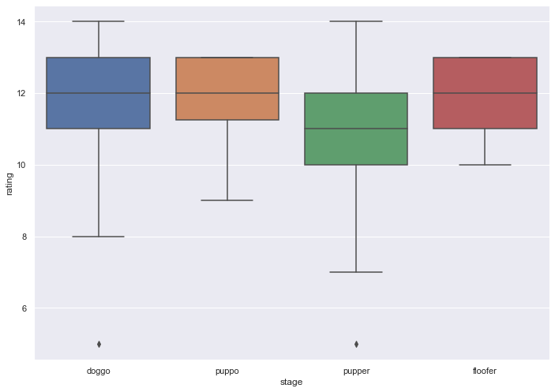

```python
sns.set(rc={'figure.figsize':(11.7,8.27)})
ax = sns.boxplot(x="stage", y="rating", data=master_df)
```

### What are the top 5 breeds with the highest favorite count

```python
master_df.groupby('breed_prediction')['favorite_count'].describe().sort_values('mean', ascending=False).reset_index()
```

|  | breed_prediction | count | mean | std | min | 25% | 50% | 75% | max |
| --- | --- | --- | --- | --- | --- | --- | --- | --- | --- |
| 0 | Angora | 8.0 | 37892.500000 | 39875.911816 | 592.0 | 592.00 | 37892.5 | 75193.00 | 75193.0 |
| 1 | Saluki | 16.0 | 24060.000000 | 18678.476440 | 3444.0 | 10886.25 | 20637.0 | 33810.75 | 51522.0 |
| 2 | French_bulldog | 104.0 | 17913.000000 | 21882.460769 | 341.0 | 3275.00 | 10421.5 | 26569.00 | 106827.0 |
| 3 | Afghan_hound | 12.0 | 17326.666667 | 8749.345631 | 7078.0 | 7078.00 | 17305.0 | 27597.00 | 27597.0 |
| 4 | giant_schnauzer | 8.0 | 17314.500000 | 18258.753525 | 235.0 | 235.00 | 17314.5 | 34394.00 | 34394.0 |
| ... | ... | ... | ... | ... | ... | ... | ... | ... | ... |
| 109 | Ibizan_hound | 12.0 | 1114.666667 | 912.508763 | 238.0 | 238.00 | 799.0 | 2307.00 | 2307.0 |
| 110 | Brabancon_griffon | 12.0 | 885.000000 | 273.499875 | 524.0 | 524.00 | 994.0 | 1137.00 | 1137.0 |
| 111 | three-toed_sloth | 4.0 | 522.000000 | 0.000000 | 522.0 | 522.00 | 522.0 | 522.00 | 522.0 |
| 112 | ibex | 4.0 | 517.000000 | 0.000000 | 517.0 | 517.00 | 517.0 | 517.00 | 517.0 |
| 113 | coho | 4.0 | 459.000000 | 0.000000 | 459.0 | 459.00 | 459.0 | 459.00 | 459.0 |

114 rows × 9 columns

Over all, the top 5 breeds with the highest favorites are : (Angora, Saluki, French_bulldog, Afghan_hound and, giant_schnauzer)

### Is there a corelation between the favorites and the retweet count

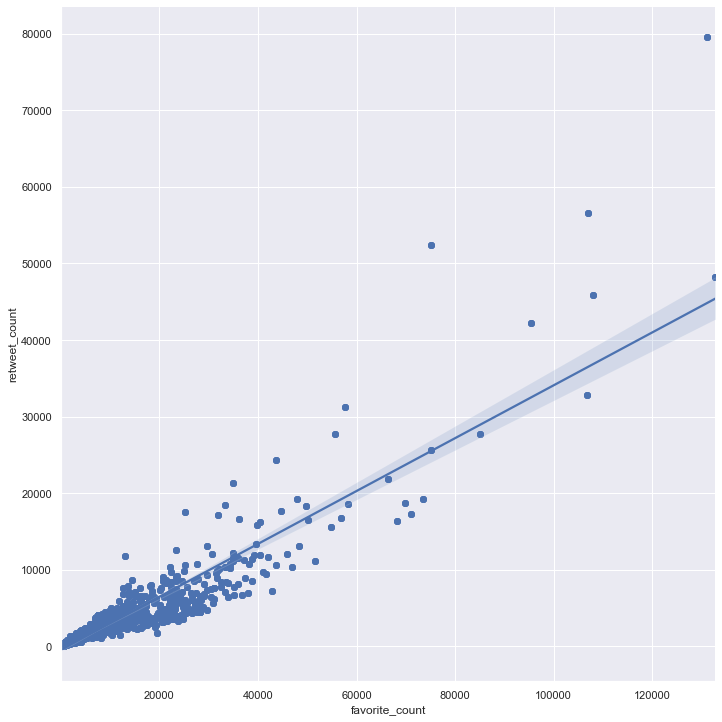

```python
p = sns.lmplot(data=master_df, x="favorite_count", y="retweet_count",height=10)
```

There seems to be a linear corelation betweeen the number of retweets and the number of favorites

### What are the top 5 most common breed

```python
master_df.groupby('breed_prediction')['tweet_id'].describe().sort_values('count', ascending=False).reset_index()
```

|  | breed_prediction | count | mean | std | min | 25% | 50% | 75% | max |
| --- | --- | --- | --- | --- | --- | --- | --- | --- | --- |
| 0 | golden_retriever | 532.0 | 7.582898e+17 | 6.798216e+16 | 6.660638e+17 | 6.998018e+17 | 7.563033e+17 | 8.131876e+17 | 8.895311e+17 |
| 1 | Labrador_retriever | 364.0 | 7.485531e+17 | 6.899989e+16 | 6.667012e+17 | 6.789692e+17 | 7.442348e+17 | 8.036381e+17 | 8.827627e+17 |
| 2 | Pembroke | 348.0 | 7.561584e+17 | 7.407651e+16 | 6.664283e+17 | 6.849022e+17 | 7.478169e+17 | 8.243256e+17 | 8.902403e+17 |
| 3 | Chihuahua | 312.0 | 7.242511e+17 | 6.932577e+16 | 6.663962e+17 | 6.728776e+17 | 6.942879e+17 | 7.771898e+17 | 8.921774e+17 |
| 4 | pug | 216.0 | 7.157859e+17 | 6.075761e+16 | 6.660829e+17 | 6.739569e+17 | 6.912594e+17 | 7.356351e+17 | 8.862584e+17 |
| ... | ... | ... | ... | ... | ... | ... | ... | ... | ... |
| 109 | EntleBucher | 4.0 | 6.798621e+17 | 0.000000e+00 | 6.798621e+17 | 6.798621e+17 | 6.798621e+17 | 6.798621e+17 | 6.798621e+17 |
| 110 | coho | 4.0 | 6.664115e+17 | 0.000000e+00 | 6.664115e+17 | 6.664115e+17 | 6.664115e+17 | 6.664115e+17 | 6.664115e+17 |
| 111 | Scotch_terrier | 4.0 | 6.892838e+17 | 0.000000e+00 | 6.892838e+17 | 6.892838e+17 | 6.892838e+17 | 6.892838e+17 | 6.892838e+17 |
| 112 | African_hunting_dog | 4.0 | 6.711633e+17 | 0.000000e+00 | 6.711633e+17 | 6.711633e+17 | 6.711633e+17 | 6.711633e+17 | 6.711633e+17 |
| 113 | groenendael | 4.0 | 6.939424e+17 | 0.000000e+00 | 6.939424e+17 | 6.939424e+17 | 6.939424e+17 | 6.939424e+17 | 6.939424e+17 |

114 rows × 9 columns

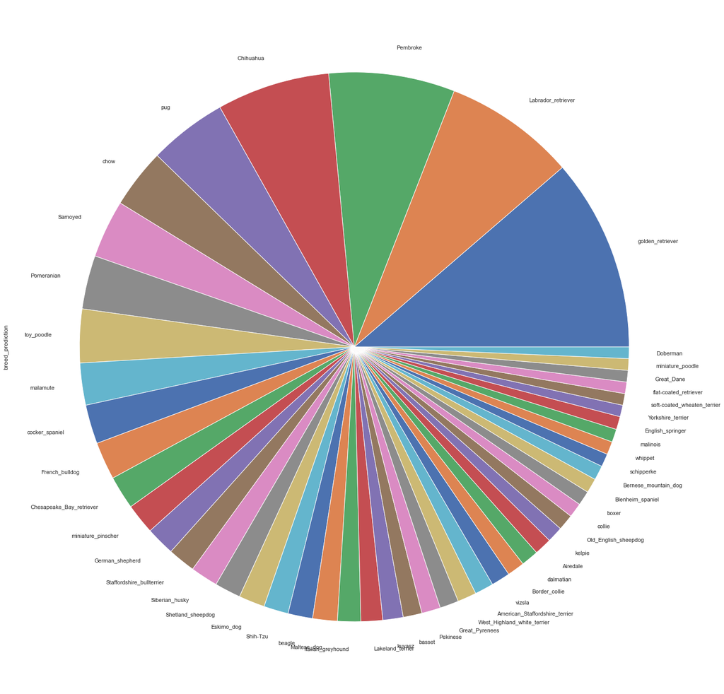

```python
plt.rcParams["figure.figsize"] = (25,25)
master_df.breed_prediction.value_counts()[:50].plot.pie()
```

The top 5 most repeeated breeds are: (golden retriever, Labrador retriever, Pembroke, Chihuahua, pug)